# Analitički izveštaj

Relja Mihić E2 5-2023

## Korišćeni podaci i tehnologije

Podaci se mogu preuzeti sa javnog izvora podataka: https://fdc.nal.usda.gov/download-datasets.html

Korišćen je skup najnovijih podataka o označenim namirnicama: **branded**, izdat *4/2024*, veličine *2.8GB*.

Učitavanje i sređivanje podataka urađeno je u programskom jeziku *R*, dok je za klasifikaciju i klasterizaciju pored tehnologije *R* korišćen *Apache Spark* kroz biblioteku *sparklyr*.

Spisak korišćenih biblioteka:

```r
library(dplyr)
library(tidyr)
library(class)
library(sparklyr)
library(data.table)
library(e1071)
library(rpart)
library(randomForest)
```

Podaci od interesa nalaze se u samo nekim od priloženih datoteka:

```r
branded_food <- read.csv("branded_food.csv")
food_nutrient <- read.csv("food_nutrient.csv")
food <- read.csv("food.csv")
measure_unit <- read.csv("measure_unit.csv")
nutrient <- read.csv("nutrient.csv")
```

Ispod je naveden sadržaj datoteka:

- *branded_food* - sadrži osnovne podatke o namirnicama
- *food_nutrient* - sadrži vrednosti i količine hranljivih materija za svaku od namirnica
- *food* - sadrži opis i dodatne informacije o namirnicama
- *measure_unit* - sadrži informacije o ključevima koji predstavljaju različite merne jedinice
- *nutrient* - sadrži informacije o ključevima koji predstavljaju različite hranljive materije

```r
food_nutrient$data_points <- NULL
food_nutrient$min <- NULL
food_nutrient$max <- NULL
food_nutrient$median <- NULL
food_nutrient$footnote <- NULL
food_nutrient$min_year_acquired <- NULL
food$food_category_id <- NULL
food$microbe_data <- NULL
branded_food[is.na(branded_food$brand_name), 3] <- ""
branded_food[is.na(branded_food$subbrand_name), 4] <- ""
branded_food[is.na(branded_food$ingredients), 6] <- ""
branded_food[is.na(branded_food$serving_size), 8] <- 0
food_nutrient[is.na(food_nutrient$derivation_id), 5] <- 0
food_description_table <- food[food$data_type == "branded_food", c(1,3,4)]
branded_food <- merge(branded_food, food_description_table, by.x="fdc_id", by.y="fdc_id", all.x=T)
```

Radi preglednosti, podaci su spojeni u jednu tabelu koja sadrži sve podatke o namirnicama. Izbačene su nepotrebne kolone tabela *food* i *food_nutrient*, kao i sređene pojave tabele *branded_food* - *NA* vrednosti su u numeričkim obeležjima poput *derivation_id* postavljene na 0, dok su kategorijska obeležja imena i opisa postavljena na prazne stringove. Kolona *Ingredients* sadrži stringove koji predstavljaju tekstove na ambalaži proizvoda, te je pogodno eliminisati naznaku na šta se tekst odnosi:

```r
branded_food$ingredients <- gsub("INGREDIENTS*: ", "", branded_food$ingredients, ignore.case=T)
branded_food$ingredients <- gsub("INGREDIENTS: ", "", branded_food$ingredients, ignore.case=T)
branded_food$ingredients <- gsub("INGREDIENT: ", "", branded_food$ingredients, ignore.case=T)
branded_food$ingredients <- gsub("MADE FROM: ", "", branded_food$ingredients, ignore.case=T)
```

Ispod je dat primer učitavanja kalorija, koje se nalaze pod imenom *Energy* u tabeli *food_nutrient*, pod odgovarajućim ključem. Postupak radi pravljenjem pomoćne tabele koja sadrži kalorijske vrednosti za svaku od namirnica. Za neke namirnice, ukupna kalorijska vrednost je prikazana po više stavki - odnosi se na npr. različita pakovanja iste hrane. Kako je broj kalorija skaliran u skupu, vrednosti se grupišu po proseku, te će za različita pakovanja iste namirnice kao kalorična vrednost biti uzet prosek.

```r
calorie_table <- food_nutrient[food_nutrient$nutrient_id == first(nutrient[nutrient$name == "Energy", 'id']), c('fdc_id','amount')]
calorie_table <- calorie_table %>% group_by(fdc_id) %>% summarise(across(amount, mean))
colnames(calorie_table)[2] <- "calories"
branded_food <- merge(branded_food, calorie_table, by.x="fdc_id", by.y="fdc_id", all.x=T)
```

```r
branded_food <- branded_food %>% drop_na(calories)

median_calories <- median(branded_food$calories)
branded_food <- branded_food %>% mutate(calories_category=ifelse(calories <= median_calories, "LOW", "HIGH"))

protein_table <- food_nutrient[food_nutrient$nutrient_id == nutrient[nutrient$name == "Protein", 'id'], c('fdc_id','amount')]
protein_table <- protein_table %>% group_by(fdc_id) %>% summarise(across(amount, mean))
colnames(protein_table)[2] <- "protein"
branded_food <- merge(branded_food, protein_table, by.x="fdc_id", by.y="fdc_id", all.x=T)
```

Slično kalorijama, potrebno je dodati sledeće makronutriente za analizu:

- Proteine, date pod nazivom *Protein*
- Masti, date pod nazivom *Total lipid (fat)*
- Ugljene hidrate, što obuhvata šećere i vlakna, date pod nazivom *Carbohydrate, by difference*, što se odnosi na metod izračunavanja količine ugljenih hidrata u hrani
- Šećere, date pod nazivom *Total Sugars*
- Vlakna, data pod nazivom *Fiber, total dietary*

Potom je potrebno srediti kategorije namirnica. Odabrana je kategorizacija po 7 grupa:

- Meso i jaja
- Mlečni proizvodi
- Žitarice i mahunarke
- Slatkiši
- Voće i povrće
- Napitci
- Supe, namazi, mešavina - opšta kategorija

Ručno su određene kategorije iz početnog skupa u ove navedene kategorije, potom su dodeljene vrednosti u tabelu. Spram količine kalorija, napravljena je podela na visoko-kalorične i nisko-kalorične namirnice.

Pojave sa nevalidnim vrednostima su bile retke, svega oko 4000 hiljada za skup od oko 1.8 miliona pojava. Te pojave nisu izbačene, već su njihove vrednosti postavljene na 0, gde će se za različite metode koristiti ili ignorisati te vrednosti:

```r
branded_food <- branded_food %>% drop_na(category_groups)
branded_food[is.na(branded_food$carbohydrates), 28] <- 0
branded_food[is.na(branded_food$protein), 27] <- 0
branded_food[is.na(branded_food$fats), 29] <- 0
branded_food[is.na(branded_food$sugars), 30] <- 0
branded_food[is.na(branded_food$fiber), 31] <- 0
```

Bitno je napomenuti da je u dokumentaciji skupa podataka navedeno da su podaci vezani za nutrijente standardizovani na po 100g proizvoda, dok postoje pojave u skupu koje imaju neke od navedenih vrednosti veće od 100, što je nemoguće, te su te vrednosti uklonjene. Slično za kalorije, koje su navedene u KCAL, gde nije moguće unutar 100g proizvoda imati više od 1000KCAL energetsku vrednost. Kako nisu pravilno date merne jedinice, te pojave se izbacuju iz skupa.

```r
branded_food <- branded_food[branded_food$calories<=1000, ]
branded_food <- branded_food[branded_food$carbohydrates<=100, ]
branded_food <- branded_food[branded_food$protein<=100, ]
branded_food <- branded_food[branded_food$fats<=100, ]
branded_food <- branded_food[branded_food$sugars<=100, ]
branded_food <- branded_food[branded_food$fiber<=100, ]

branded_food$carbohydrates <- pmax(branded_food$carbohydrates, branded_food$sugars)
branded_food$carbohydrates <- pmax(branded_food$carbohydrates, branded_food$fiber)
```

Takođe, nije moguće da proizvod ima više šećera ili više vlakana od ugljenih hidrata, pa se u slučaju da je vrednost kolona *sugars* ili *fiber* veća od vrednosti ugljenih hidrata, ugljeni hidrati postavljaju na odgovarajuću vrednost

Nad sređenim skupom možemo videti karakteristike obeležja od interesa:

```r
branded_food <- branded_food[, c(2:5, 21, 6:13, 22, 14:20, 1, 30, 31, 23:29)]
branded_food <- branded_food %>% drop_na(category_groups)
rm(calorie_table, carb_table, fat_table, fiber_table, food, food_description_table, food_nutrient, groups_table, measure_unit, nutrient, protein_table, sugar_table, unique_cats, median_calories)

branded_food[is.na(branded_food$carbohydrates), 28] <- 0
branded_food[is.na(branded_food$protein), 27] <- 0
branded_food[is.na(branded_food$fats), 29] <- 0
branded_food[is.na(branded_food$sugars), 30] <- 0
branded_food[is.na(branded_food$fiber), 31] <- 0
```

Ispod su dati graficki prikazi vezani za podatke:

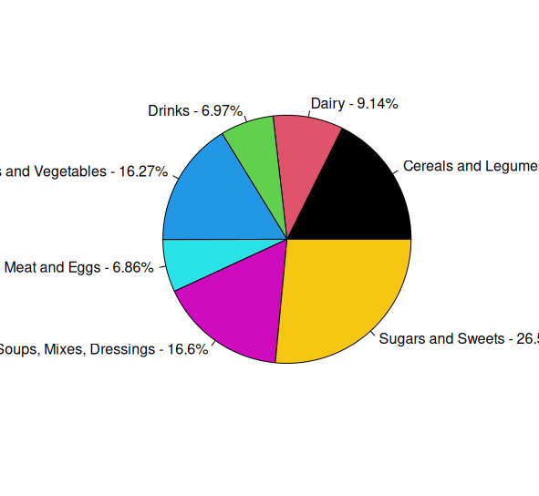

Tortni grafikon predstavlja podelu namirnica spram tipa. Najčešći tip grupe kategorija su Šećeri i Slatkiši sa preko četvrtinu ukupnog skupa podataka. Podaci su relativno balansirani spram kategorija, jer je najmanja kategorija, *meso* preko 5% ukupnog skupa.

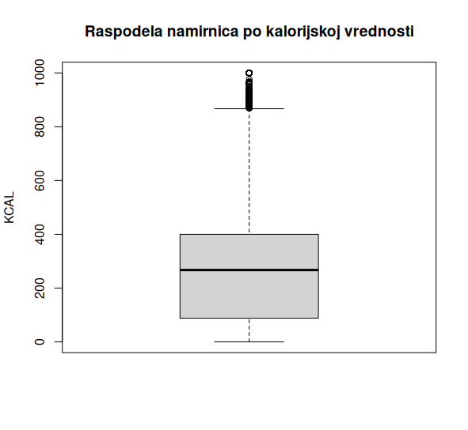

Već je spomenuto da kalorijska vrednost ne može biti veća od 1000 KCAL po 100g, to je prikazano i na kutijastom grafikonu. Većina namirnica ima manje od 400 kilokalorija, dok su manjina njih ispod 100 kilokalorija. Dalje su prikazane raspodele pojedinačno za svaki od učitanih makronutrijenata:

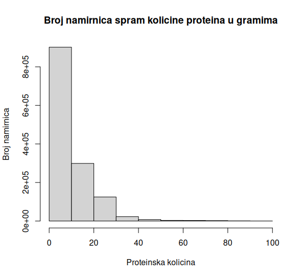

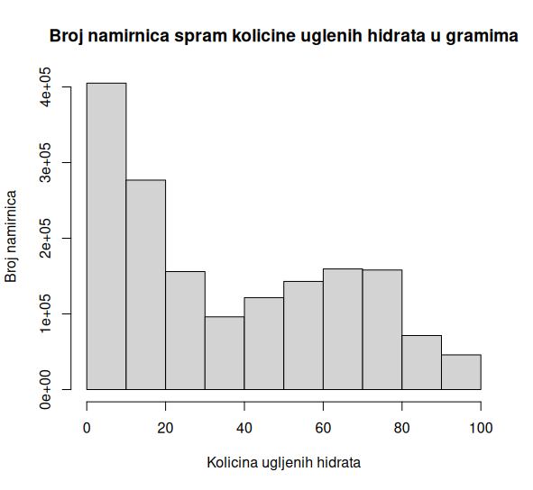

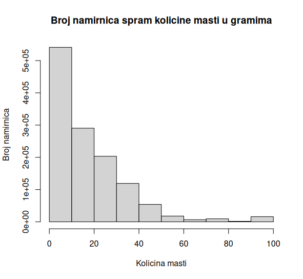

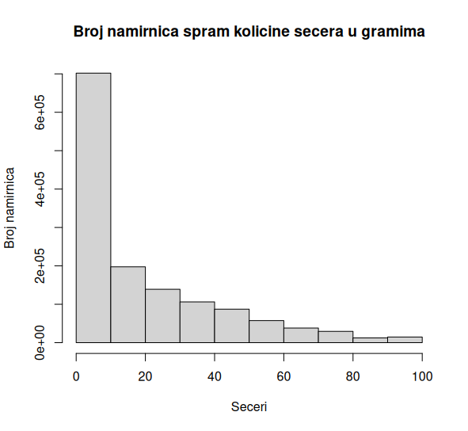

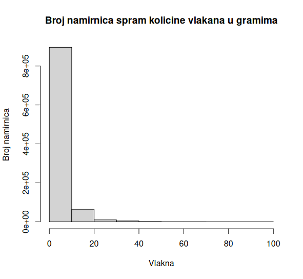

Sem deskriptivnog opisa relevantnih kategorija, važna je i veza između makronutrienata. U delu ispod prikazan je odnos ugljenih hidrata sa ostalim makronutrientima, gde boje predstavljaju pripadnost visokokaloričnoj ili niskokaloričnoj hrani. Moguće je da namirnica sa velikom količinom ugljenih hidrata, proteina ili masti bude u niskokalorijskoj kategoriji, jer je za različite ugljene hidrate, proteine ili masti različita kalorijska vrednost. Specifični tipovi mikronutrijenata postoje u ulaznom skupu, ali su retki i većina proizvoda nema podatke o njima, izdvojeni su samo šećeri i vlakna.

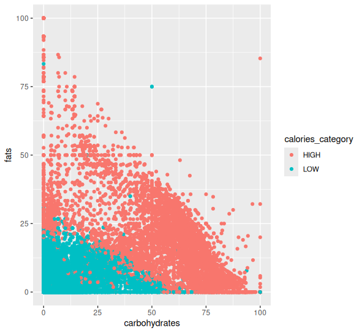

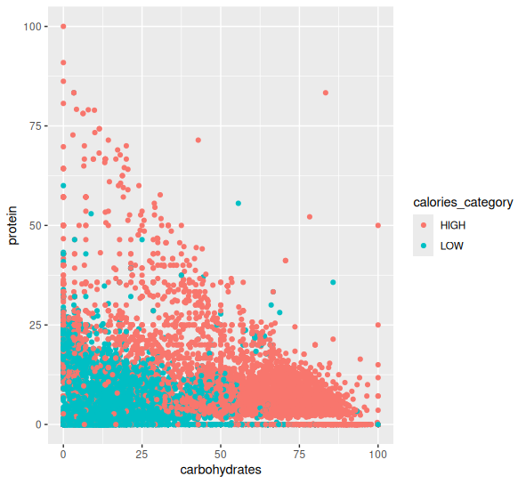

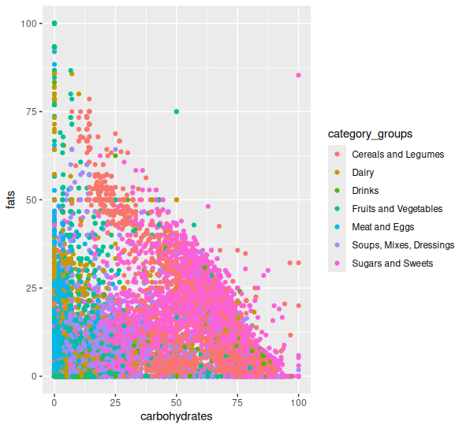

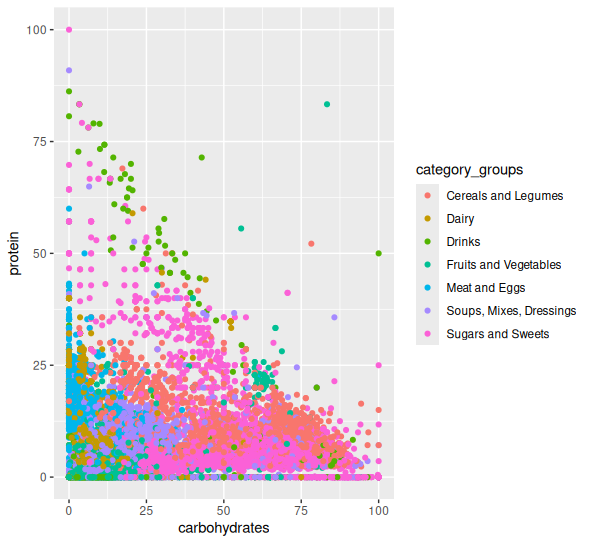

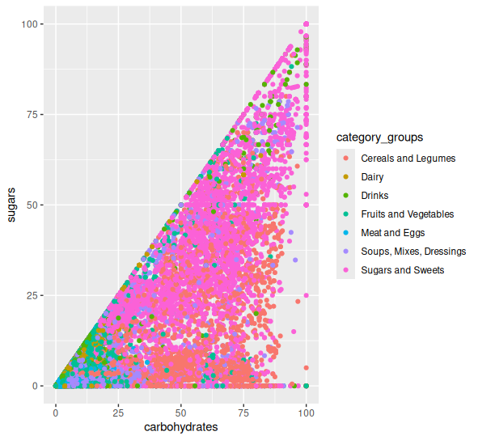

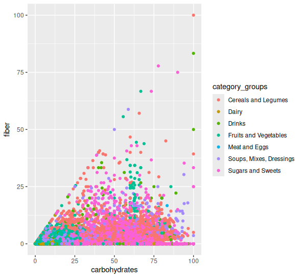

##Metode klasifikacije za kalorijske kateogrije i njihova preciznost:

Klasifikacija je odrađena koristeći 3 različite metode, za 3 scenarija, sve za dva različita pitanja:

1. Klasifikacija namirnica spram makronutrienata u visokokalorične i niskokalorične namirnice
2. Klasifikacija namirnica spram makronutrienata u različite grupe namirnica

Za klasifikaciju kaloričnosti korišćene su metode KNN, SVM i random forrest. Unakrsna validacija je urađena koristeći petinu inicijalnog skupa, a podela odrađena ručno:

```r
test_sets <- list()
train_sets <- list()
i <- sample(nrow(knn_food), 0.2 * nrow(knn_food))
test_sets[[1]] <- knn_food[i, ]
train_sets[[1]] <- knn_food[-i, ]
remainder <- knn_food[-i, ]
rm(i)
i <- sample(nrow(remainder), 0.2 * nrow(knn_food))
test_sets[[2]] <- remainder[i, ]
train_sets[[2]] <- knn_food[-i, ]
remainder <- remainder[-i, ]
rm(i)
i <- sample(nrow(remainder), 0.2 * nrow(knn_food))
test_sets[[3]] <- remainder[i, ]
train_sets[[3]] <- knn_food[-i, ]
remainder <- remainder[-i, ]
rm(i)
i <- sample(nrow(remainder), 0.2 * nrow(knn_food))
test_sets[[4]] <- remainder[i, ]
train_sets[[4]] <- knn_food[-i, ]
remainder <- remainder[-i, ]
i <- sample(nrow(remainder), nrow(remainder))
test_sets[[5]] <- remainder[i, ]
train_sets[[5]] <- knn_food[-i, ]
rm(i)
rm(remainder)
```

Za svaku od metoda podešavaju se odgovarajući parametri. Što se tiče metode *k najbližih suseda*, podešavan je parametar k, kao i odrađena metoda za različite formule odnosno kombinacije makronutrijenata. Istražena je veza između samo osnovnih makronutrienata i makronutrienata uključujući šećer i vlakna. Što se tiče metode potpornih vektora, odrađeno je testiranje spram različitih funkcija korišćenih kao kernel funkcija i tu su isprobane *sigmoidna* *polinomijalna* i *radijalna*. Najbolje rezultate dala je radijalna, dok najgore sigmoidalna kernel funkcija. Treća metoda klasifikacije koja je korišćena je *random forrest*, sa podešavanim brojem stabala. Sve metode su dale veliku preciznost, što je i očekivano za odnos kalorija i makronutrijenata. Postoje i formule koje aproksimiraju konkretan broj kalorija spram makronutrijenata. Deo koda prikazan ispod pokazuje primenu unakrsne validacije za metodu *k unakrsnih suseda*, i rezultati su prikazani na grafiku ispod:

```r
total_perf <- list()
for(k_iter in 1:6) {
  total_perf[[k_iter]] <- 0
  for(i in 1:5) {
    if(k_iter %% 2 == 1) {
      rez_knn <- knn(select(train_sets[[i]], protein, fats, carbohydrates), select(test_sets[[i]], protein, fats, carbohydrates), train_sets[[i]]$calories_category, k = (k_iter) * 5, use.all = FALSE)
    } else {
      rez_knn <- knn(select(train_sets[[i]], protein, fats, carbohydrates, sugars, fiber), select(test_sets[[i]], protein, fats, carbohydrates, sugars, fiber), train_sets[[i]]$calories_category, k = (k_iter-1) * 5, use.all = FALSE)
    }
    perf_knn <- rez_knn == as.factor(test_sets[[i]]$calories_category)
    perf_knn <- sum(perf_knn, na.rm=TRUE) / length(perf_knn)
    total_perf[[k_iter]] <- total_perf[[k_iter]] + perf_knn
  }
  total_perf[[k_iter]] <- total_perf[[k_iter]] / 5
}
total_perf_knn <- total_perf
```

[figure not shown]

## Metode klasifikacije za kategorije grupa hrana i njihova preciznost

Korišćene su metode klasifikacije iz alata *Apache Spark*, za šta je potrebno uspostaviti konekciju i proslediti tabelu na spark klaster. Ovo je odrađeno ispisom tabele u CSV, potom učitavanja novokreirane datoteke u Spark. Na kraju je nakon obrade zatvorena konekcija.

```r
konekcija <- spark_connect(master="local")
spark_web(konekcija)
food_arranged <- food_arranged %>% drop_na()
fwrite(food_arranged, file="~/Desktop/master/rvpii/projekat/FDC/food_arranged.csv")
food_arranged_tbl <- spark_read_csv(konekcija, name="food_arranged_tbl", path="~/Desktop/master/rvpii/projekat/FDC/food_arranged.csv", memory=T, infer_schema=F, columns=list(publication_date="character",modified_date="character",available_date="character",market_country="character",discontinued_date="character",category_groups_num="integer",category_groups="character",calories="double",calories_category="character",protein="double",carbohydrates="double",fats="double",sugars="double",fiber="double"))
```

```r
forr_pipeline <- ml_pipeline(konekcija) %>%
  ft_dplyr_transformer(tbl=food_arranged_tbl %>% filter(!is.na(protein) & !is.na(fats) & !is.na(carbohydrates) & !is.na(sugars) & !is.na(fiber) & !is.na(category_groups_num))) %>%
  ft_r_formula(category_groups_num ~ protein + fats + carbohydrates) %>%
  ml_random_forest_classifier(label_col = "category_groups_num")
fv <- ml_cross_validator(konekcija, estimator=forr_pipeline, estimator_param_maps=list(random_forest=list(num_trees = c(3,5), max_depth = c(3, 5))),evaluator=ml_multiclass_classification_evaluator(konekcija), num_folds = 5, parallelism = 4)
fv_model <- ml_fit(fv, food_arranged_tbl)
fv_metrics <- ml_validation_metrics(fv_model)
plot(fv_metrics$max_depth_1, fv_metrics$f1)
plot(fv_metrics$num_trees_1, fv_metrics$f1)
```

## Naive Bayes

[output not shown]

## Logistička Regresija

| f1 | max_iter |
| --- | --- |
| 0.4209302 | 3 |
| 0.4563971 | 5 |
| 0.4461019 | 10 |

## Random Forrest

Random Forrest F1

| f1 | num_trees | max_depth |
| --- | --- | --- |
| 0.4541276 | 3 | 3 |
| 0.4822375 | 5 | 3 |
| 0.6124540 | 3 | 5 |
| 0.6132587 | 5 | 5 |

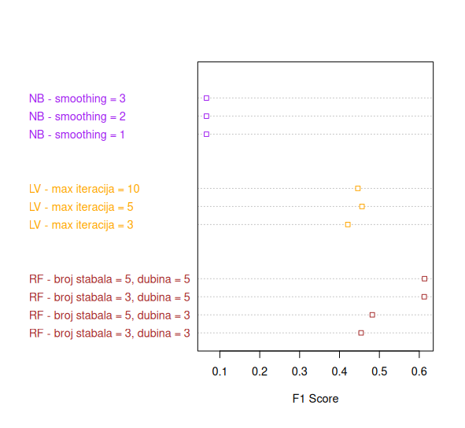

## Klasterizacija spram šećera i vlakana:

Odabrana metoda za obe klasterizacije je *metod k sredina*, gde je odrađena klasterizacija spram šećera i vlakana, kao i spram glavnih makronutrijenata: proteina, masti, ugljenih hidrata. Korišćene su dve funkcije za evaluaciju, na kraju je uzeta mera Siluete.

- 0.8589299 za 2 klastera
- 0.8157849 za 3 klastera
- 0.7488397 za 4 klastera
- 0.7488397 za 5 klastera

## Klasterizacija spram proteina, masti, ugljenih hidrata:

```r
eval_vec <- c(0,0,0,0,0,0,0,0,0,0)
eval_s2 <- c(0,0,0,0,0,0,0,0,0,0)
for(i in 1:10) {
  klast <- ml_kmeans(food_arranged_tbl, calories_category ~ protein + fats + carbohydrates, k = i+1, max_iter = 25, init_mode = "random")
  klast$model$summary$cluster_sizes()
  klast.eval <- ml_evaluate(klast, food_arranged_tbl %>% select(protein, fats, carbohydrates))
  eval_s2[i] <- ml_compute_silhouette_measure(klast, food_arranged_tbl, distance_measure = "Manhattan")
  eval_vec[i] <- klast.eval
}
```

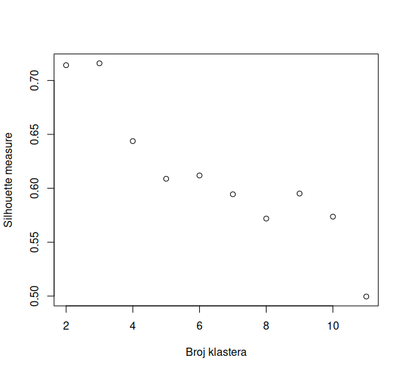